# Credit Card Fraud Detection

Ming Ming Zhang

## Abstract

We detect anomalous behaviour in credit card transactions using the [dataset](https://www.kaggle.com/mlg-ulb/creditcardfraud). In the dataset, there are 492 anomalies out of 284,807 transactions, and each transaction is described by 30 features and 1 label. Among the 30 features, there are 28 features transformed by PCA and 2 (non-transformed) features called “Time” and “Amount”. The label called “Class” is denoted by 1 if the transaction is a fraud, and 0 otherwise. Since the dataset is highly imbalanced, the $F_{1}$ score is used.

The problem can be solved by supervised learning and anomaly detection. For the supervised learning, the dataset will be divided into 3 parts: 60% normal and oversampling anomalous transactions for training (or undersampling normal and 60% anomalous transactions for training), 20% normal and 20% anomalous transactions for cross-validation, and the rest 20% normal and 20% anomalous transactions for testing. For the anomaly detection, 60% normal transactions for training, 20% normal and 50% anomalous transactions for cross-validation, and the rest 20% normal and 50% anomalous transactions for testing. In particular, we will use logistic regression with regularization and Gaussian models. The results on the test sets are summarized as follows. Note that all parameters are optimized by the cross-validation sets.

```r
resSupervised = data.frame("Supervised Model"=c("Logistic Regression with Oversampling","Logistic Regression with Undersampling"),
                     "Regularized Parameter"=c(0,2010),
                     Threshold=c(0.9,0.5),
                     Precision=c(0.42,0.92),
                     Recall=c(0.848,0.808),
                     F1=c(0.562,0.86))
print(resSupervised)
```

| Supervised.Model | Regularized.Parameter | Threshold | Precision | Recall | F1 |
| --- | --- | --- | --- | --- | --- |
| Logistic Regression with Oversampling | 0 | 0.9 | 0.42 | 0.848 | 0.562 |
| Logistic Regression with Undersampling | 2010 | 0.5 | 0.92 | 0.808 | 0.860 |

```r
resAnomaly = data.frame("Anomaly Detection"=c("Gaussian","Multivariate Gaussian","Multivariate Gaussian"),
                     Features=c("All","All","Some"),
                     Threshold=c(1.609*10^(-114),1.323*10^(-142),1.007*10^(-52)),
                     Precision=c(0.311,0.568,0.917),
                     Recall=c(0.366,0.732,0.764),
                     F1=c(0.336,0.639,0.834))
print(resAnomaly)
```

| Anomaly.Detection | Features | Threshold | Precision | Recall | F1 |
| --- | --- | --- | --- | --- | --- |
| Gaussian | All | 1.609e-114 | 0.311 | 0.366 | 0.336 |
| Multivariate Gaussian | All | 1.323e-142 | 0.568 | 0.732 | 0.639 |
| Multivariate Gaussian | Some | 1.007e-52 | 0.917 | 0.764 | 0.834 |

The performance of the multivariate Gaussian model with selected features (the last row in the 2nd table) is close to the one using logistic regression with regularization trained on undersampling normal dataset (the last row in the 1st table). However, the former model requires selecting features carefully. By using logistic regression with regularization, we are able to refine a subset of features based on the $F_{1}$ score; and then we apply multivariate Gaussian model on the refined dataset.

Note that we implement logistic regression with regularization, Gaussian and Multivariate Gaussian models in R, and algorithms to select the regularized parameter and threshold using $F_{1}$ score on a cross-validation set.

## The data

```r
fraud = read.csv("~/Downloads/Data/CreditCardFraudDetection/creditcard.csv")
fraud = cbind(scale(fraud[,-ncol(fraud)]), Class=fraud[,ncol(fraud)])
fraud0 = fraud[fraud[,ncol(fraud)]==0,]
fraud1 = fraud[fraud[,ncol(fraud)]==1,]
set.seed(123)
idx0 = sample(1:nrow(fraud0))
idx1 = sample(1:nrow(fraud1))
fraud0 = fraud0[idx0,]
fraud1 = fraud1[idx1,]
dim(fraud)
```

```
[1] 284807     31
```

```r
paste("# non-fraud:", nrow(fraud0), "# fraud:", nrow(fraud1), "The ratio:", nrow(fraud1)/nrow(fraud))
```

```
[1] "# non-fraud: 284315 # fraud: 492 The ratio: 0.00172748563062003"
```

## Logistic regression

### Splitting data

```r
ratioTrain = 0.6
ratioVal = 0.2
ratioTest = 0.2
XY_train0 = splitData(fraud0, ratioTrain, ratioVal, ratioTest)[[1]]
XY_val0 = splitData(fraud0, ratioTrain, ratioVal, ratioTest)[[2]]
XY_test0 = splitData(fraud0, ratioTrain, ratioVal, ratioTest)[[3]]
XY_train1 = splitData(fraud1, ratioTrain, ratioVal, ratioTest)[[1]]
XY_val1 = splitData(fraud1, ratioTrain, ratioVal, ratioTest)[[2]]
XY_test1 = splitData(fraud1, ratioTrain, ratioVal, ratioTest)[[3]]
```

#### Undersampling and oversampling

```r
set.seed(123)
# Undersampling
idx_under = sample(1:nrow(XY_train0), size = nrow(fraud1), replace = F)
XY_train0_under = XY_train0[idx_under,]
XY_train_under = rbind(XY_train0_under, XY_train1)
XY_train_under = XY_train_under[sample(1:nrow(XY_train_under)),]
X_train_under = XY_train_under[,-ncol(XY_train_under)]
y_train_under = XY_train_under[,ncol(XY_train_under)]
# Oversampling
idx_over = sample(1:nrow(XY_train1), size = nrow(XY_train0), replace = T)
XY_train1_over = XY_train1[idx_over,]
XY_train_over = rbind(XY_train0, XY_train1_over)
XY_train_over = XY_train_over[sample(1:nrow(XY_train_over)),]
X_train_over = XY_train_over[,-ncol(XY_train_over)]
y_train_over = XY_train_over[,ncol(XY_train_over)]
XY_val = rbind(XY_val0, XY_val1)
XY_val = XY_val[sample(1:nrow(XY_val)),]
X_val = XY_val[,-ncol(XY_val)]
y_val = XY_val[,ncol(XY_val)]
XY_test = rbind(XY_test0, XY_test1)
XY_test = XY_test[sample(1:nrow(XY_test)),]
X_test = XY_test[,-ncol(XY_test)]
y_test = XY_test[,ncol(XY_test)]
```

### Oversampling

#### Leanring curve

```
$error_train
[1] 0.07248888 0.06085368 0.06266268 0.06125941

$error_val
[1] 0.9592102 0.8940702 0.8873239 0.8906714

$figure
```

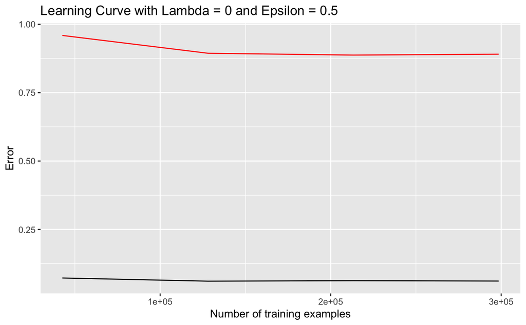

```r
lambda = 0
maxit = 100
epsilon = 0.5
learningCurve(X_train_over, y_train_over, X_val, y_val, lambda, maxit, epsilon)
```

The learning curve indicates that the logistic regression with oversampling is not a good model to use.

#### Evaluation

```r
lambda = 0
maxit = 500
modelLog_over = logLearning(X_train_over, y_train_over, lambda, maxit)
thetaLog_over = modelLog_over$par
epsilon = 0.5
F1(y_test, logPredict(X_test, thetaLog_over, epsilon))
```

```
$precision
[1] 0.06111484

$recall
[1] 0.9191919

$F1
[1] 0.1146096
```

#### Selecting threshold

```
$epsilon
 [1] 0.0 0.1 0.2 0.3 0.4 0.5 0.6 0.7 0.8 0.9 1.0

$evaluation
 [1] 0.003435041 0.006263520 0.018133232 0.039265358 0.075348075 0.115796098 0.165454545 0.220570012 0.336483932
[10] 0.580858086 0.000000000

$figure
```

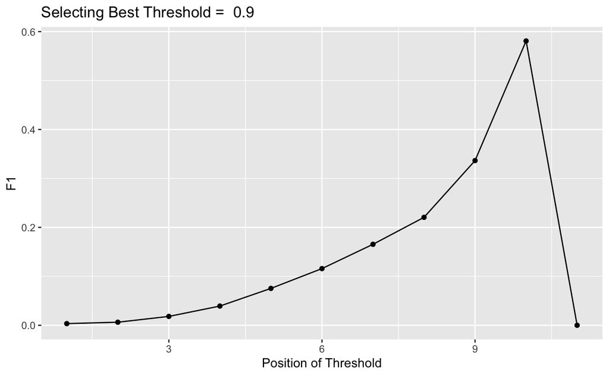

```r
theta = thetaLog_over
selectThreshold(X_val, y_val, theta, epsilons = seq(0, 1, by = 0.1))
```

```r
lambda = 0
maxit = 500
modelLog_over = logLearning(X_train_over, y_train_over, lambda, maxit)
thetaLog_over = modelLog_over$par
epsilon = 0.9
F1(y_test, logPredict(X_test, thetaLog_over, epsilon))
```

```
$precision
[1] 0.42

$recall
[1] 0.8484848

$F1
[1] 0.5618729
```

```
$error_train
[1] 0.10457347 0.08966936 0.09211427 0.09184522

$error_val
[1] 0.2293578 0.4220779 0.4210526 0.4152824

$figure
```

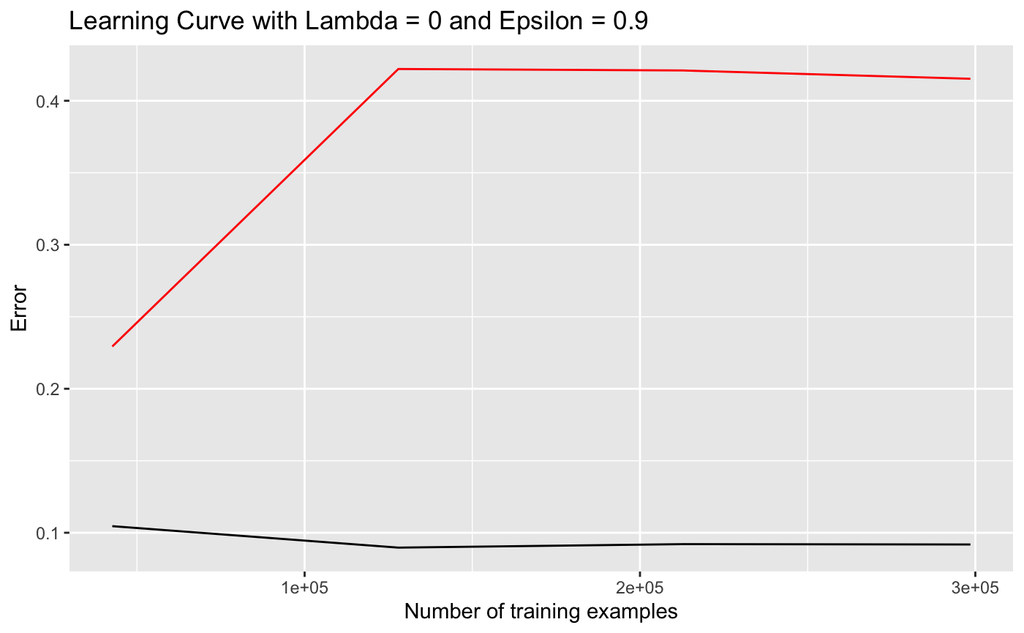

```r
lambda = 0
maxit = 100
epsilon = 0.9
learningCurve(X_train_over, y_train_over, X_val, y_val, lambda, maxit, epsilon)
```

With threshold adjusted, it is still not a good model.

### Undersampling

#### Leanring curve

```
$error_train
[1] 0.00000000 0.04147465 0.05586592 0.06451613

$error_val
[1] 0.9104781 0.9125841 0.9062822 0.8808901

$figure
```

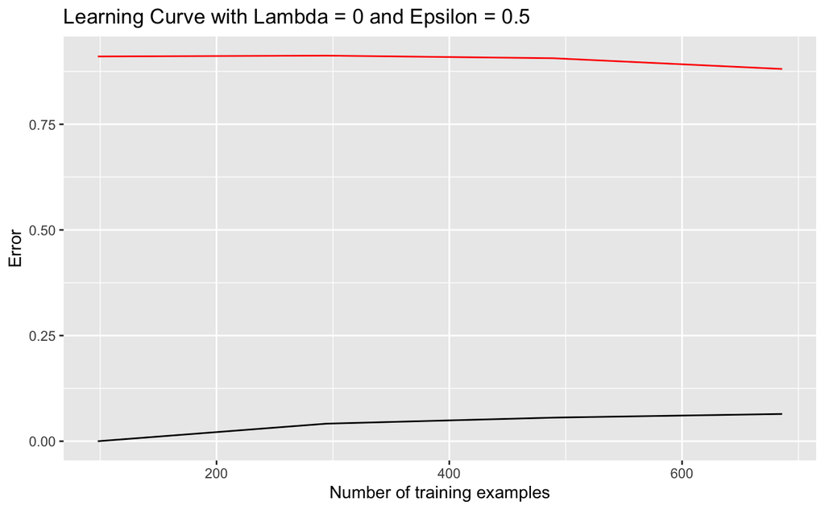

```r
lambda = 0
maxit = 100
epsilon = 0.5
learningCurve(X_train_under, y_train_under, X_val, y_val, lambda, maxit, epsilon)
```

#### Selecting Lambda

```
$error_train
[1] 0.06216696 0.08226691 0.09057301 0.10902256 0.13243762 0.13461538 0.23430962

$error_val
[1] 0.8719772 0.7244582 0.3333333 0.1980676 0.1413613 0.1428571 0.2919255

$figure
```

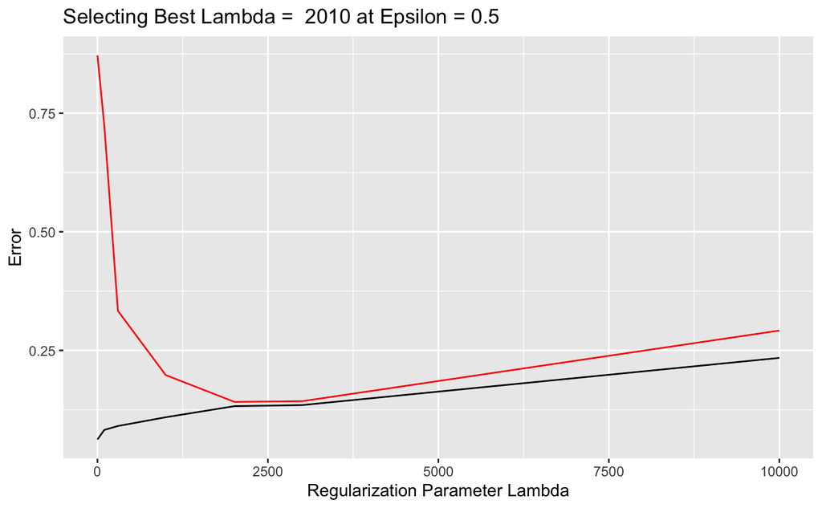

```r
lambda_vec = c(0, 100, 300, 1000, 2010, 3000, 10000)
epsilon = 0.5
selectLambda(X_train_under, y_train_under, X_val, y_val, lambda_vec, maxit, epsilon)
```

#### Evaluation

```r
lambda = 2010
maxit = 500
modelLog_under = logLearning(X_train_under, y_train_under, lambda, maxit)
thetaLog_under = modelLog_under$par
epsilon = 0.5
F1(y_test, logPredict(X_test, thetaLog_under, epsilon))
```

```
$precision
[1] 0.9195402

$recall
[1] 0.8080808

$F1
[1] 0.8602151
```

```
$error_train
[1] 0.1875000 0.1789474 0.1543210 0.1409692

$error_val
[1] 0.3333333 0.1693989 0.1428571 0.1413613

$figure
```

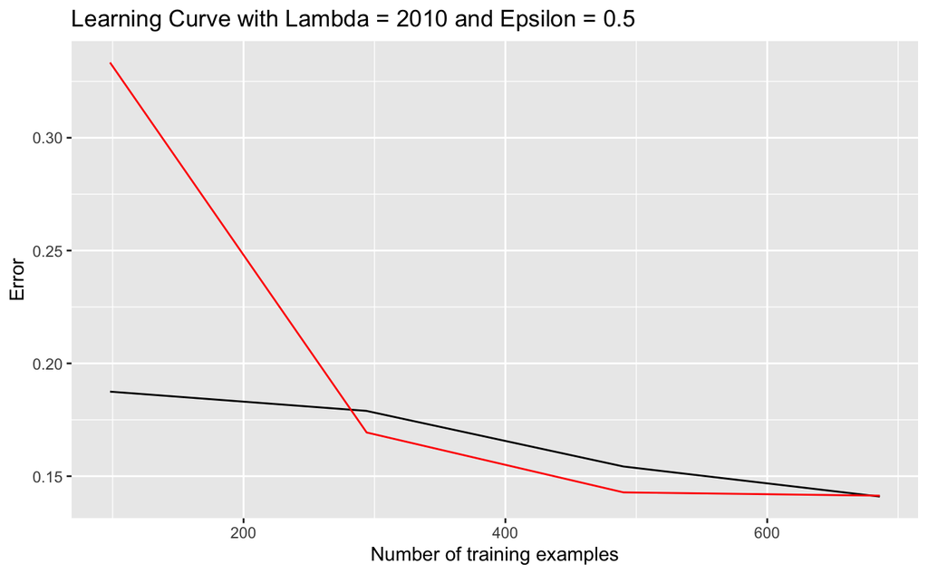

```r
lambda = 2010
maxit = 500
epsilon = 0.5
learningCurve(X_train_under, y_train_under, X_val, y_val, lambda, maxit, epsilon)
```

#### Selecting threshold

```
$epsilon
 [1] 0.0 0.1 0.2 0.3 0.4 0.5 0.6 0.7 0.8 0.9 1.0

$evaluation
 [1] 0.003435041 0.003438174 0.077506318 0.719008264 0.798076923 0.858638743 0.830601093 0.703703704 0.636363636
[10] 0.470588235 0.000000000

$figure
```

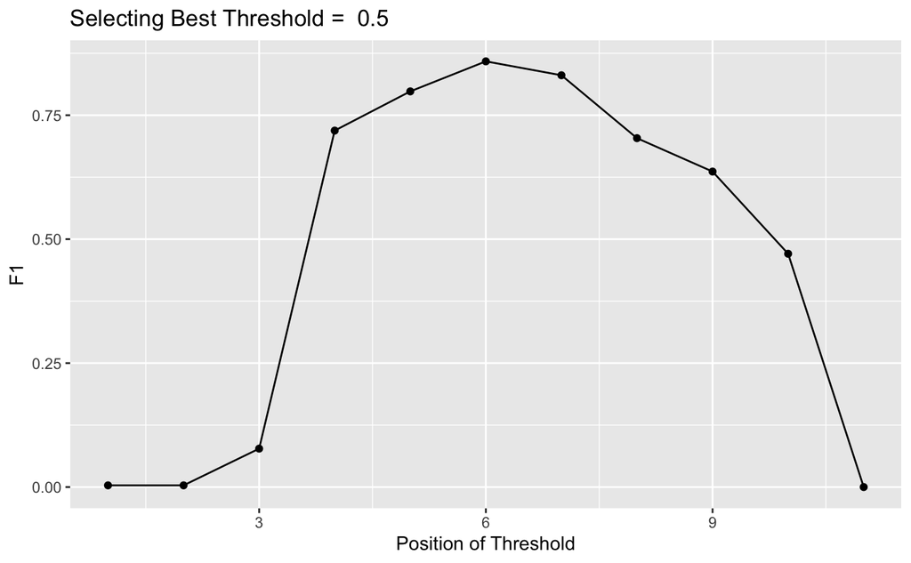

```r
theta = thetaLog_under
selectThreshold(X_val, y_val, theta, epsilons = seq(0, 1, by = 0.1))
```

#### Ranking features

```r
theta_under = thetaLog_under[-1]
names(theta_under) = 1:ncol(X_test)
theta_under = sort(abs(theta_under), decreasing = T)
theta_under
```

```
          15           13            5           11           12            4           18           17           10
0.1410713743 0.0835529274 0.0730559109 0.0655743076 0.0602699690 0.0585511517 0.0529563963 0.0456694612 0.0341967787
           8            2            3            7           22           30            9           14           28
0.0232718344 0.0202460954 0.0196157811 0.0193667888 0.0181063661 0.0130801184 0.0123577628 0.0117854432 0.0088196143
          29           19           24           21           25           20           26           23           16
0.0082739066 0.0068130919 0.0052923256 0.0042357707 0.0041775385 0.0037777793 0.0030547216 0.0024841519 0.0021480051
           6            1           27
0.0019102438 0.0009890864 0.0004082608
```

```r
featureRank_under = names(theta_under)
(featureRank_under = as.numeric(featureRank_under))
```

```
 [1] 15 13  5 11 12  4 18 17 10  8  2  3  7 22 30  9 14 28 29 19 24 21 25 20 26 23 16  6  1 27
```

## Gaussian model

### Splitting data

```r
set.seed(123)
# 60% non-fraud for training, 20% non-fraud and 50% fraud for validation, the rest 20% non-fraud and 50% fraud for test
ratioTrain = 0.6
ratioVal = 0.2
ratioTest = 0.2
XY_train = splitData(fraud0, ratioTrain, ratioVal, ratioTest)[[1]]
XY_val0 = splitData(fraud0, ratioTrain, ratioVal, ratioTest)[[2]]
XY_test0 = splitData(fraud0, ratioTrain, ratioVal, ratioTest)[[3]]
XY_val1 = fraud1[1:floor(0.5*nrow(fraud1)),]
XY_test1 = fraud1[(floor(0.5*nrow(fraud1))+1):nrow(fraud1),]
X_train = XY_train[,-ncol(XY_train)]
y_train = XY_train[,ncol(XY_train)]
XY_val = rbind(XY_val0, XY_val1)
XY_val = XY_val[sample(1:nrow(XY_val)),]
X_val = XY_val[,-ncol(XY_val)]
y_val = XY_val[,ncol(XY_val)]
XY_test = rbind(XY_test0, XY_test1)
XY_test = XY_test[sample(1:nrow(XY_test)),]
X_test = XY_test[,-ncol(XY_test)]
y_test = XY_test[,ncol(XY_test)]
```

### Gaussian model with all features

```r
mu = estimateGaussian(X_train)[[1]]
sigma2 = estimateGaussian(X_train)[[2]]
p_val = multivariateGaussian(X_val, mu, sigma2)
stepsize = 10^2
L1 = selectThresholdGaussian(y_val, p_val, stepsize)
paste(stepsize, L1)
```

```
[1] "100 1.60916656632736e-15" "100 0.0120712351903828"
```

```r
stepsize = 10^3
L2 = selectThresholdGaussian(y_val, p_val, stepsize)
paste(stepsize, L2)
```

```
[1] "1000 1.60916656632736e-16" "1000 0.0163190058379707"
```

```
$bestEpsilon
[1] 1.609167e-114

$bestF1
[1] 0.3945312

$figure
```

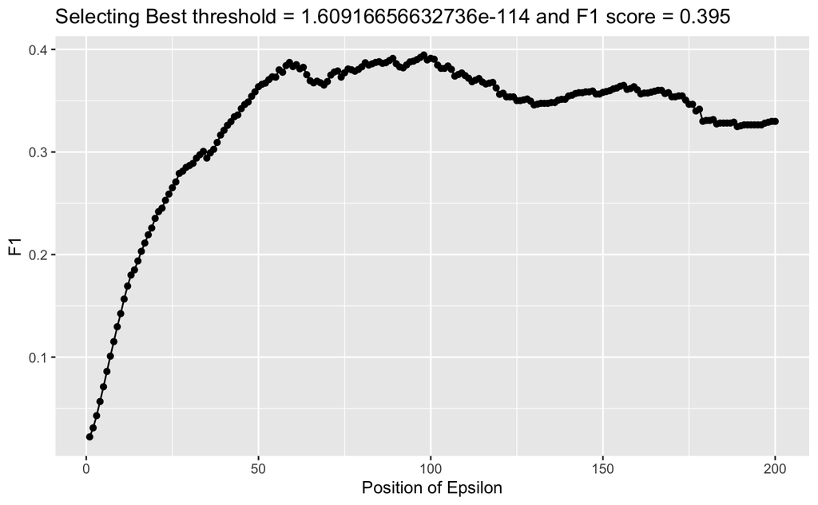

```r
# When stepsize increases, epsilon is the multiple of the previous one and F1 score increases. To find the best threshold, we therefore increase the power of epsilon.
#epsilon = as.numeric(formatC(L2[[1]], format = "e", digits = 3))
epsilon = L2[[1]]
L3 = selectThresholdGaussianFurther(y_val, p_val, epsilon)
L3
```

```r
p_test = multivariateGaussian(X_test, mu, sigma2)
TestPredictions = ifelse(p_test<L3[[1]], 1, 0)
F1(y_test, TestPredictions)
```

```
$precision
[1] 0.3114187

$recall
[1] 0.3658537

$F1
[1] 0.3364486
```

```r
paste("# outliers found:", sum(p_test<epsilons[which.max(f1Scores)]))
```

```
[1] "# outliers found: 289"
```

### Multivariate Gaussian with all features

```r
mu = estimateMultiGaussian(X_train)[[1]]
Sigma = estimateMultiGaussian(X_train)[[2]]
p_val = multivariateGaussian(X_val, mu, Sigma)
stepsize = 10^2
L1 = selectThresholdGaussian(y_val, p_val, stepsize)
paste(stepsize, L1)
```

```
[1] "100 1.32333933711781e-14" "100 0.012640778214165"
```

```r
stepsize = 10^3
L2 = selectThresholdGaussian(y_val, p_val, stepsize)
paste(stepsize, L2)
```

```
[1] "1000 1.32333933711781e-15" "1000 0.0170118869670439"
```

```
$bestEpsilon
[1] 1.323339e-142

$bestF1
[1] 0.6423358

$figure
```

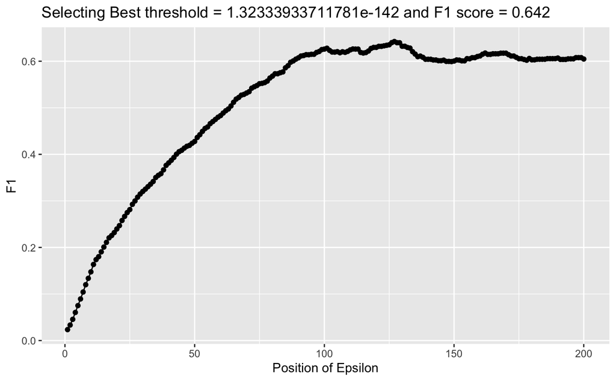

```r
# When stepsize increases, epsilon is the multiple of the previous one and F1 score increases. To find the best threshold, we therefore increase the power of epsilon.
#epsilon = as.numeric(formatC(L2[[1]], format = "e", digits = 3))
epsilon = L2[[1]]
L3 = selectThresholdGaussianFurther(y_val, p_val, epsilon)
L3
```

```r
p_test = multivariateGaussian(X_test, mu, Sigma)
TestPredictions = ifelse(p_test<L3[[1]], 1, 0)
F1(y_test, TestPredictions)
```

```
$precision
[1] 0.5678233

$recall
[1] 0.7317073

$F1
[1] 0.6394316
```

```r
paste("# outliers found:", sum(p_test<L3[[1]]))
```

```
[1] "# outliers found: 317"
```

### Multivariate Gaussian with a subset of features

```r
X_train_reduced = X_train[,featureRank_under]
X_val_reduced = X_val[,featureRank_under]
X_test_reduced = X_test[,featureRank_under]
```

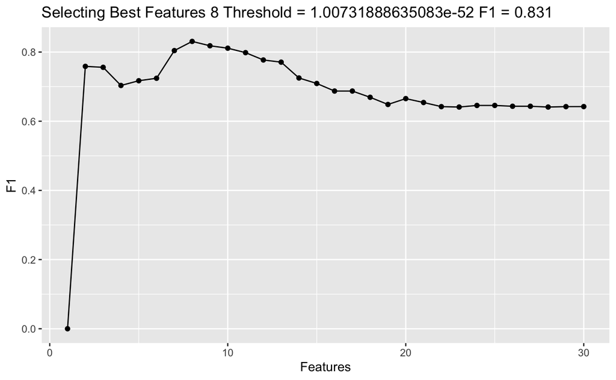

```r
Eps = rep(0, ncol(X_train_reduced))
F1s = rep(0, ncol(X_train_reduced))
for (j in 2:ncol(X_train_reduced)) {
  mu = estimateMultiGaussian(X_train_reduced[,1:j])[[1]]
  Sigma = estimateMultiGaussian(X_train_reduced[,1:j])[[2]]
  p_val = multivariateGaussian(X_val_reduced[,1:j], mu, Sigma)
  stepsize = 10^2
  L = selectThresholdGaussian(y_val, p_val, stepsize)
  epsilon = L[[1]]
  L1 = selectThresholdGaussianFurther(y_val, p_val, epsilon)
  Eps[j] = L1[[1]]
  F1s[j] = L1[[2]]
}
library(ggplot2)
ggplot(data.frame(Eps=1:ncol(X_train_reduced), F1=F1s), aes(Eps, F1)) + geom_point() + geom_line() +
  xlab("Features") +
  ggtitle(paste("Selecting Best Features", which.max(F1s), "Threshold =", Eps[which.max(F1s)], "F1 =", round(F1s[which.max(F1s)],3)))
```

```r
cat("Columns name:",colnames(X_train_reduced[,1:which.max(F1s)]))
```

```
Columns name: V14 V12 V4 V10 V11 V3 V17 V16
```

```r
mu = estimateMultiGaussian(X_train_reduced[,1:8])[[1]]
Sigma = estimateMultiGaussian(X_train_reduced[,1:8])[[2]]
p_val = multivariateGaussian(X_val_reduced[,1:8], mu, Sigma)
stepsize = 10^2
L1 = selectThresholdGaussian(y_val, p_val, stepsize)
paste(stepsize, L1)
```

```
[1] "100 1.00731888635083e-05" "100 0.0360073289253565"
```

```r
stepsize = 10^3
L2 = selectThresholdGaussian(y_val, p_val, stepsize)
paste(stepsize, L2)
```

```
[1] "1000 1.00731888635083e-06" "1000 0.070874861572536"
```

```
$bestEpsilon
[1] 1.007319e-52

$bestF1
[1] 0.8307692

$figure
```

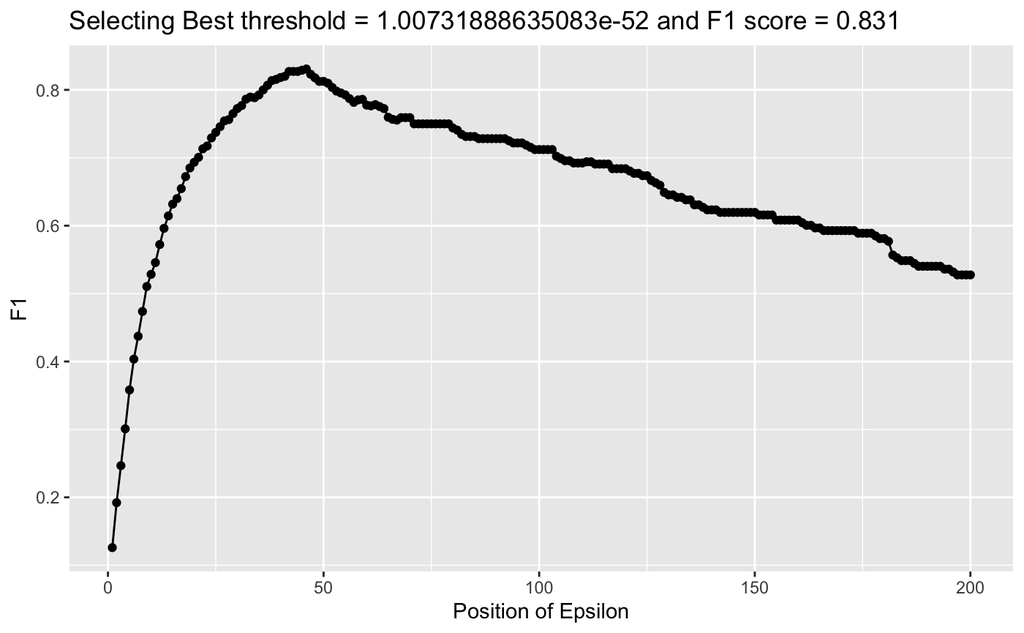

```r
# When stepsize increases, epsilon is the multiple of the previous one and F1 score increases. To find the best threshold, we therefore increase the power of epsilon.
epsilon = L2[[1]]
L3 = selectThresholdGaussianFurther(y_val, p_val, epsilon)
L3
```

```r
p_test = multivariateGaussian(X_test_reduced[,1:8], mu, Sigma)
TestPredictions = ifelse(p_test<L3[[1]], 1, 0)
F1(y_test, TestPredictions)
```

```
$precision
[1] 0.9170732

$recall
[1] 0.7642276

$F1
[1] 0.8337029
```

```r
paste("# outliers found:", sum(p_test<L3[[1]]))
```

```
[1] "# outliers found: 205"
```